# DIFseq User Guide

# 8 Model Selection using BIC

If we have no prior knowledge about the cell type number, we vary the number of cell types `K` by changing the `n.celltype` slot in the DIFseq object and rerun the MCEM algorithm to compute the corresponding BIC. Finally, the optimal cell type number will achieve the minimum value of BIC. The `BIC_DIFseq` function returns the BIC values in a `DIFseq` object.

In this example, the underlying true number of cell types is three. For an illustration, we vary `K` from 2 to 5.

```r
K_vec <- 2:5
BIC_values <- rep(NA, length(K_vec))

DIFseq_list <- list()

for(k in K_vec){

  message("Running for the number of cell types K = ",k,"...")
  DIFseq_list[[k-1]] <- Object
  DIFseq_list[[k-1]]@n.celltype <- k

  DIFseq_list[[k-1]] <- DIFseq_MCEM(DIFseq_list[[k-1]], count = "counts",
                                    working_dir = "../DIFseq_test/", correction = FALSE)

  BIC_values[k-1] <- BIC_DIFseq(DIFseq_list[[k-1]])
  message("The BIC at K = ",k," is ", BIC_values[k-1],".")
}
```

```
## Running for the number of cell types K = 2...
```

```
##    conducting MCEM algorithm...
```

```
##    The MCEM algorithm takes: 2.828 mins
```

```
## The BIC at K = 2 is 3086302.27878002.
```

```
## Running for the number of cell types K = 3...
```

```
##    conducting MCEM algorithm...
```

```
##    The MCEM algorithm takes: 3.115 mins
```

```
## The BIC at K = 3 is 2877187.96422778.
```

```
## Running for the number of cell types K = 4...
```

```
##    conducting MCEM algorithm...
```

```
##    The MCEM algorithm takes: 4.476 mins
```

```
## The BIC at K = 4 is 2879881.65926036.
```

```
## Running for the number of cell types K = 5...
```

```
##    conducting MCEM algorithm...
```

```
##    The MCEM algorithm takes: 4.54 mins
```

```
## The BIC at K = 5 is 2883094.25814071.
```

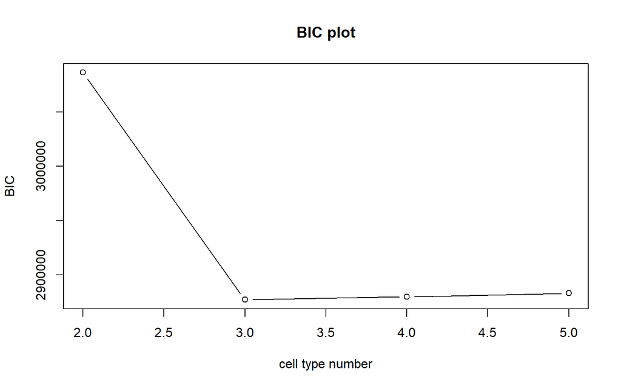

```r
plot(K_vec, BIC_values,
     xlab="cell type number", ylab="BIC",
     main="BIC plot", type="b")
```

The BIC attains the minimum at K = 3, thus correctly recovering the true cell type number by BIC.

# References

1.

Segerstolpe, Å. *et al.* Single-cell transcriptome profiling of human pancreatic islets in health and type 2 diabetes. *Cell Metabolism* **24**, 593–607 (2016).

2.

Arunachalam, P. S. *et al.* Systems biological assessment of immunity to mild versus severe COVID-19 infection in humans. *Science* **369**, 1210–1220 (2020).

3.

Lin, Y., Cao, Y., Willie, E., Patrick, E. & Yang, J. Y. Atlas-scale single-cell multi-sample multi-condition data integration using scMerge2. *Nature Communications* **14**, 4272 (2023).

4.

Ritchie, M. E. *et al.* Limma powers differential expression analyses for RNA-sequencing and microarray studies. *Nucleic Acids Research* **43**, e47–e47 (2015).

5.

Anders, S. & Huber, W. Differential expression analysis for sequence count data. *Genome Biology* **11**, R106 (2010).

6.

McCarthy, D. J., Chen, Y. & Smyth, G. K. Differential expression analysis of multifactor RNA-seq experiments with respect to biological variation. *Nucleic Acids Research* **40**, 4288–4297 (2012).